# LIS Oyster Lab Tissue Processing

Updated 12/27/23/2023 by M. Kachmar

### This code chunk merges all .csv files within the Tissue processing folder into one data frame and outputs the full dataset into a .csv master file. This allows us to download the raw data as a .csv, add it to the repository folder, and create the master data file without copying and pasting data in excel.

# reading in .csv files from local folder

```r
data_all <- list.files(path = "C:/Users/mariah.kachmar/Documents/Github/EAD-ASEB_EPA_LISS_Disease_Surveillance/Lab_Data_TissueProcessing/Files_by_Month",                           # Identify all CSV files
  pattern = "*.csv", full.names = TRUE) %>%
  lapply(read_csv) %>%     # Store all files in list
  bind_rows                                         # Combine data sets into one data set
data_all                                            # Print data to RStudio console
```

| lab_id | date_collected | site | lab_sample | oyster_zone | light_regime | date_processed | ww_total_g | height_mm | length_mm | width_mm | condition | dissection_notes | mantle_rftm | ggr1_etoh...15 | ggr1_etoh...16 | adductor_etoh | cross_histology | date_davidsons | date_etoh | ...21 | ...22 | ...23 | ...24 | ...25 | ...26 | ...27 | ...28 | ...29 | ...30 | … |
| --- | --- | --- | --- | --- | --- | --- | --- | --- | --- | --- | --- | --- | --- | --- | --- | --- | --- | --- | --- | --- | --- | --- | --- | --- | --- | --- | --- | --- | --- | --- |
| 0423ASHC_01 | 2023-04-23 | ASHC | 1 | upper | NA | 2023-04-25 | 70.64 | 98.50 | 51.96 | 24.48 | medium | NA | TRUE | TRUE | TRUE | TRUE | TRUE | 2023-04-25 | 2023-04-26 | NA | NA | NA | NA | NA | NA | NA | NA | NA | NA | … |
| 0423ASHC_02 | 2023-04-23 | ASHC | 2 | upper | NA | 2023-04-25 | 78.83 | 101.82 | 56.09 | 26.11 | medium | NA | TRUE | TRUE | TRUE | TRUE | TRUE | 2023-04-25 | 2023-04-26 | NA | NA | NA | NA | NA | NA | NA | NA | NA | NA | … |
| 0423ASHC_03 | 2023-04-23 | ASHC | 3 | upper | NA | 2023-04-25 | 61.52 | 109.94 | 48.01 | 21.45 | medium | NA | TRUE | TRUE | TRUE | TRUE | TRUE | 2023-04-25 | 2023-04-26 | NA | NA | NA | NA | NA | NA | NA | NA | NA | NA | … |
| 0423ASHC_04 | 2023-04-23 | ASHC | 4 | upper | NA | 2023-04-25 | 66.62 | 79.13 | 54.84 | 23.51 | medium | NA | TRUE | TRUE | TRUE | TRUE | TRUE | 2023-04-25 | 2023-04-26 | NA | NA | NA | NA | NA | NA | NA | NA | NA | NA | … |
| 0423ASHC_05 | 2023-04-23 | ASHC | 5 | upper | NA | 2023-04-25 | 68.72 | 104.60 | 52.72 | 17.76 | medium | NA | TRUE | TRUE | TRUE | TRUE | TRUE | 2023-04-25 | 2023-04-26 | NA | NA | NA | NA | NA | NA | NA | NA | NA | NA | … |
| 0423ASHC_06 | 2023-04-23 | ASHC | 6 | upper | NA | 2023-04-25 | 74.57 | 110.50 | 50.23 | 27.24 | medium | NA | TRUE | TRUE | TRUE | TRUE | TRUE | 2023-04-25 | 2023-04-26 | NA | NA | NA | NA | NA | NA | NA | NA | NA | NA | … |
| 0423ASHC_07 | 2023-04-23 | ASHC | 7 | lower | NA | 2023-04-25 | 39.13 | 75.70 | 43.52 | 22.18 | medium | NA | TRUE | TRUE | TRUE | TRUE | TRUE | 2023-04-25 | 2023-04-26 | NA | NA | NA | NA | NA | NA | NA | NA | NA | NA | … |
| 0423ASHC_08 | 2023-04-23 | ASHC | 8 | upper | NA | 2023-04-25 | 84.88 | 111.31 | 55.33 | 22.61 | medium | NA | TRUE | TRUE | TRUE | TRUE | TRUE | 2023-04-25 | 2023-04-26 | NA | NA | NA | NA | NA | NA | NA | NA | NA | NA | … |
| 0423ASHC_09 | 2023-04-23 | ASHC | 9 | upper | NA | 2023-04-25 | 87.33 | 117.85 | 54.61 | 27.72 | medium | NA | TRUE | TRUE | TRUE | TRUE | TRUE | 2023-04-25 | 2023-04-26 | NA | NA | NA | NA | NA | NA | NA | NA | NA | NA | … |
| 0423ASHC_10 | 2023-04-23 | ASHC | 10 | upper | NA | 2023-04-25 | 155.33 | 134.28 | 69.73 | 25.95 | medium | NA | TRUE | TRUE | TRUE | TRUE | TRUE | 2023-04-25 | 2023-04-26 | NA | NA | NA | NA | NA | NA | NA | NA | NA | NA | … |

[output cut: 990 more lines]

```r
as.data.frame(data_all)  # Convert tibble to data.frame
```

| lab_id | date_collected | site | lab_sample | oyster_zone | light_regime | date_processed | ww_total_g | height_mm | length_mm | width_mm | condition | dissection_notes | mantle_rftm | ggr1_etoh...15 | ggr1_etoh...16 | adductor_etoh | cross_histology | date_davidsons | date_etoh | ...21 | ...22 | ...23 | ...24 | ...25 | ...26 | ...27 | ...28 | ...29 | ...30 | … |
| --- | --- | --- | --- | --- | --- | --- | --- | --- | --- | --- | --- | --- | --- | --- | --- | --- | --- | --- | --- | --- | --- | --- | --- | --- | --- | --- | --- | --- | --- | --- |
| 0423ASHC_01 | 2023-04-23 | ASHC | 1 | upper | NA | 2023-04-25 | 70.64 | 98.50 | 51.96 | 24.48 | medium | NA | TRUE | TRUE | TRUE | TRUE | TRUE | 2023-04-25 | 2023-04-26 | NA | NA | NA | NA | NA | NA | NA | NA | NA | NA | … |
| 0423ASHC_02 | 2023-04-23 | ASHC | 2 | upper | NA | 2023-04-25 | 78.83 | 101.82 | 56.09 | 26.11 | medium | NA | TRUE | TRUE | TRUE | TRUE | TRUE | 2023-04-25 | 2023-04-26 | NA | NA | NA | NA | NA | NA | NA | NA | NA | NA | … |
| 0423ASHC_03 | 2023-04-23 | ASHC | 3 | upper | NA | 2023-04-25 | 61.52 | 109.94 | 48.01 | 21.45 | medium | NA | TRUE | TRUE | TRUE | TRUE | TRUE | 2023-04-25 | 2023-04-26 | NA | NA | NA | NA | NA | NA | NA | NA | NA | NA | … |
| 0423ASHC_04 | 2023-04-23 | ASHC | 4 | upper | NA | 2023-04-25 | 66.62 | 79.13 | 54.84 | 23.51 | medium | NA | TRUE | TRUE | TRUE | TRUE | TRUE | 2023-04-25 | 2023-04-26 | NA | NA | NA | NA | NA | NA | NA | NA | NA | NA | … |
| 0423ASHC_05 | 2023-04-23 | ASHC | 5 | upper | NA | 2023-04-25 | 68.72 | 104.60 | 52.72 | 17.76 | medium | NA | TRUE | TRUE | TRUE | TRUE | TRUE | 2023-04-25 | 2023-04-26 | NA | NA | NA | NA | NA | NA | NA | NA | NA | NA | … |
| 0423ASHC_06 | 2023-04-23 | ASHC | 6 | upper | NA | 2023-04-25 | 74.57 | 110.50 | 50.23 | 27.24 | medium | NA | TRUE | TRUE | TRUE | TRUE | TRUE | 2023-04-25 | 2023-04-26 | NA | NA | NA | NA | NA | NA | NA | NA | NA | NA | … |
| 0423ASHC_07 | 2023-04-23 | ASHC | 7 | lower | NA | 2023-04-25 | 39.13 | 75.70 | 43.52 | 22.18 | medium | NA | TRUE | TRUE | TRUE | TRUE | TRUE | 2023-04-25 | 2023-04-26 | NA | NA | NA | NA | NA | NA | NA | NA | NA | NA | … |
| 0423ASHC_08 | 2023-04-23 | ASHC | 8 | upper | NA | 2023-04-25 | 84.88 | 111.31 | 55.33 | 22.61 | medium | NA | TRUE | TRUE | TRUE | TRUE | TRUE | 2023-04-25 | 2023-04-26 | NA | NA | NA | NA | NA | NA | NA | NA | NA | NA | … |
| 0423ASHC_09 | 2023-04-23 | ASHC | 9 | upper | NA | 2023-04-25 | 87.33 | 117.85 | 54.61 | 27.72 | medium | NA | TRUE | TRUE | TRUE | TRUE | TRUE | 2023-04-25 | 2023-04-26 | NA | NA | NA | NA | NA | NA | NA | NA | NA | NA | … |
| 0423ASHC_10 | 2023-04-23 | ASHC | 10 | upper | NA | 2023-04-25 | 155.33 | 134.28 | 69.73 | 25.95 | medium | NA | TRUE | TRUE | TRUE | TRUE | TRUE | 2023-04-25 | 2023-04-26 | NA | NA | NA | NA | NA | NA | NA | NA | NA | NA | … |

[output cut: 990 more lines]

```r
#Filtering NAs
data_all <- data_all %>% filter(!is.na(date_collected))
data_all
```

| lab_id | date_collected | site | lab_sample | oyster_zone | light_regime | date_processed | ww_total_g | height_mm | length_mm | width_mm | condition | dissection_notes | mantle_rftm | ggr1_etoh...15 | ggr1_etoh...16 | adductor_etoh | cross_histology | date_davidsons | date_etoh | ...21 | ...22 | ...23 | ...24 | ...25 | ...26 | ...27 | ...28 | ...29 | ...30 | … |
| --- | --- | --- | --- | --- | --- | --- | --- | --- | --- | --- | --- | --- | --- | --- | --- | --- | --- | --- | --- | --- | --- | --- | --- | --- | --- | --- | --- | --- | --- | --- |
| 0423ASHC_01 | 2023-04-23 | ASHC | 1 | upper | NA | 2023-04-25 | 70.64 | 98.50 | 51.96 | 24.48 | medium | NA | TRUE | TRUE | TRUE | TRUE | TRUE | 2023-04-25 | 2023-04-26 | NA | NA | NA | NA | NA | NA | NA | NA | NA | NA | … |
| 0423ASHC_02 | 2023-04-23 | ASHC | 2 | upper | NA | 2023-04-25 | 78.83 | 101.82 | 56.09 | 26.11 | medium | NA | TRUE | TRUE | TRUE | TRUE | TRUE | 2023-04-25 | 2023-04-26 | NA | NA | NA | NA | NA | NA | NA | NA | NA | NA | … |
| 0423ASHC_03 | 2023-04-23 | ASHC | 3 | upper | NA | 2023-04-25 | 61.52 | 109.94 | 48.01 | 21.45 | medium | NA | TRUE | TRUE | TRUE | TRUE | TRUE | 2023-04-25 | 2023-04-26 | NA | NA | NA | NA | NA | NA | NA | NA | NA | NA | … |
| 0423ASHC_04 | 2023-04-23 | ASHC | 4 | upper | NA | 2023-04-25 | 66.62 | 79.13 | 54.84 | 23.51 | medium | NA | TRUE | TRUE | TRUE | TRUE | TRUE | 2023-04-25 | 2023-04-26 | NA | NA | NA | NA | NA | NA | NA | NA | NA | NA | … |
| 0423ASHC_05 | 2023-04-23 | ASHC | 5 | upper | NA | 2023-04-25 | 68.72 | 104.60 | 52.72 | 17.76 | medium | NA | TRUE | TRUE | TRUE | TRUE | TRUE | 2023-04-25 | 2023-04-26 | NA | NA | NA | NA | NA | NA | NA | NA | NA | NA | … |
| 0423ASHC_06 | 2023-04-23 | ASHC | 6 | upper | NA | 2023-04-25 | 74.57 | 110.50 | 50.23 | 27.24 | medium | NA | TRUE | TRUE | TRUE | TRUE | TRUE | 2023-04-25 | 2023-04-26 | NA | NA | NA | NA | NA | NA | NA | NA | NA | NA | … |
| 0423ASHC_07 | 2023-04-23 | ASHC | 7 | lower | NA | 2023-04-25 | 39.13 | 75.70 | 43.52 | 22.18 | medium | NA | TRUE | TRUE | TRUE | TRUE | TRUE | 2023-04-25 | 2023-04-26 | NA | NA | NA | NA | NA | NA | NA | NA | NA | NA | … |
| 0423ASHC_08 | 2023-04-23 | ASHC | 8 | upper | NA | 2023-04-25 | 84.88 | 111.31 | 55.33 | 22.61 | medium | NA | TRUE | TRUE | TRUE | TRUE | TRUE | 2023-04-25 | 2023-04-26 | NA | NA | NA | NA | NA | NA | NA | NA | NA | NA | … |
| 0423ASHC_09 | 2023-04-23 | ASHC | 9 | upper | NA | 2023-04-25 | 87.33 | 117.85 | 54.61 | 27.72 | medium | NA | TRUE | TRUE | TRUE | TRUE | TRUE | 2023-04-25 | 2023-04-26 | NA | NA | NA | NA | NA | NA | NA | NA | NA | NA | … |
| 0423ASHC_10 | 2023-04-23 | ASHC | 10 | upper | NA | 2023-04-25 | 155.33 | 134.28 | 69.73 | 25.95 | medium | NA | TRUE | TRUE | TRUE | TRUE | TRUE | 2023-04-25 | 2023-04-26 | NA | NA | NA | NA | NA | NA | NA | NA | NA | NA | … |

[output cut: 830 more lines]

```r
write.csv(data_all, "C:/Users/mariah.kachmar/Documents/Github/EAD-ASEB_EPA_LISS_Disease_Surveillance/Lab_Data_TissueProcessing\\All_tissue_processing_data.csv", row.names=FALSE)

data_all
```

| lab_id | date_collected | site | lab_sample | oyster_zone | light_regime | date_processed | ww_total_g | height_mm | length_mm | width_mm | condition | dissection_notes | mantle_rftm | ggr1_etoh...15 | ggr1_etoh...16 | adductor_etoh | cross_histology | date_davidsons | date_etoh | ...21 | ...22 | ...23 | ...24 | ...25 | ...26 | ...27 | ...28 | ...29 | ...30 | … |
| --- | --- | --- | --- | --- | --- | --- | --- | --- | --- | --- | --- | --- | --- | --- | --- | --- | --- | --- | --- | --- | --- | --- | --- | --- | --- | --- | --- | --- | --- | --- |
| 0423ASHC_01 | 2023-04-23 | ASHC | 1 | upper | NA | 2023-04-25 | 70.64 | 98.50 | 51.96 | 24.48 | medium | NA | TRUE | TRUE | TRUE | TRUE | TRUE | 2023-04-25 | 2023-04-26 | NA | NA | NA | NA | NA | NA | NA | NA | NA | NA | … |
| 0423ASHC_02 | 2023-04-23 | ASHC | 2 | upper | NA | 2023-04-25 | 78.83 | 101.82 | 56.09 | 26.11 | medium | NA | TRUE | TRUE | TRUE | TRUE | TRUE | 2023-04-25 | 2023-04-26 | NA | NA | NA | NA | NA | NA | NA | NA | NA | NA | … |
| 0423ASHC_03 | 2023-04-23 | ASHC | 3 | upper | NA | 2023-04-25 | 61.52 | 109.94 | 48.01 | 21.45 | medium | NA | TRUE | TRUE | TRUE | TRUE | TRUE | 2023-04-25 | 2023-04-26 | NA | NA | NA | NA | NA | NA | NA | NA | NA | NA | … |
| 0423ASHC_04 | 2023-04-23 | ASHC | 4 | upper | NA | 2023-04-25 | 66.62 | 79.13 | 54.84 | 23.51 | medium | NA | TRUE | TRUE | TRUE | TRUE | TRUE | 2023-04-25 | 2023-04-26 | NA | NA | NA | NA | NA | NA | NA | NA | NA | NA | … |
| 0423ASHC_05 | 2023-04-23 | ASHC | 5 | upper | NA | 2023-04-25 | 68.72 | 104.60 | 52.72 | 17.76 | medium | NA | TRUE | TRUE | TRUE | TRUE | TRUE | 2023-04-25 | 2023-04-26 | NA | NA | NA | NA | NA | NA | NA | NA | NA | NA | … |
| 0423ASHC_06 | 2023-04-23 | ASHC | 6 | upper | NA | 2023-04-25 | 74.57 | 110.50 | 50.23 | 27.24 | medium | NA | TRUE | TRUE | TRUE | TRUE | TRUE | 2023-04-25 | 2023-04-26 | NA | NA | NA | NA | NA | NA | NA | NA | NA | NA | … |
| 0423ASHC_07 | 2023-04-23 | ASHC | 7 | lower | NA | 2023-04-25 | 39.13 | 75.70 | 43.52 | 22.18 | medium | NA | TRUE | TRUE | TRUE | TRUE | TRUE | 2023-04-25 | 2023-04-26 | NA | NA | NA | NA | NA | NA | NA | NA | NA | NA | … |
| 0423ASHC_08 | 2023-04-23 | ASHC | 8 | upper | NA | 2023-04-25 | 84.88 | 111.31 | 55.33 | 22.61 | medium | NA | TRUE | TRUE | TRUE | TRUE | TRUE | 2023-04-25 | 2023-04-26 | NA | NA | NA | NA | NA | NA | NA | NA | NA | NA | … |
| 0423ASHC_09 | 2023-04-23 | ASHC | 9 | upper | NA | 2023-04-25 | 87.33 | 117.85 | 54.61 | 27.72 | medium | NA | TRUE | TRUE | TRUE | TRUE | TRUE | 2023-04-25 | 2023-04-26 | NA | NA | NA | NA | NA | NA | NA | NA | NA | NA | … |
| 0423ASHC_10 | 2023-04-23 | ASHC | 10 | upper | NA | 2023-04-25 | 155.33 | 134.28 | 69.73 | 25.95 | medium | NA | TRUE | TRUE | TRUE | TRUE | TRUE | 2023-04-25 | 2023-04-26 | NA | NA | NA | NA | NA | NA | NA | NA | NA | NA | … |

[output cut: 830 more lines]

```r
NA
```

## adding a month column to the data

```r
data_all <- data_all %>%
  mutate(date_collected= as.Date(date_collected), month = month(date_collected))

data_all
```

| lab_id | date_collected | site | lab_sample | oyster_zone | light_regime | date_processed | ww_total_g | height_mm | length_mm | width_mm | condition | dissection_notes | mantle_rftm | ggr1_etoh...15 | ggr1_etoh...16 | adductor_etoh | cross_histology | date_davidsons | date_etoh | ...21 | ...22 | ...23 | ...24 | ...25 | ...26 | ...27 | ...28 | ...29 | ...30 | … |
| --- | --- | --- | --- | --- | --- | --- | --- | --- | --- | --- | --- | --- | --- | --- | --- | --- | --- | --- | --- | --- | --- | --- | --- | --- | --- | --- | --- | --- | --- | --- |
| 0423ASHC_01 | 2023-04-23 | ASHC | 1 | upper | NA | 2023-04-25 | 70.64 | 98.50 | 51.96 | 24.48 | medium | NA | TRUE | TRUE | TRUE | TRUE | TRUE | 2023-04-25 | 2023-04-26 | NA | NA | NA | NA | NA | NA | NA | NA | NA | NA | … |
| 0423ASHC_02 | 2023-04-23 | ASHC | 2 | upper | NA | 2023-04-25 | 78.83 | 101.82 | 56.09 | 26.11 | medium | NA | TRUE | TRUE | TRUE | TRUE | TRUE | 2023-04-25 | 2023-04-26 | NA | NA | NA | NA | NA | NA | NA | NA | NA | NA | … |
| 0423ASHC_03 | 2023-04-23 | ASHC | 3 | upper | NA | 2023-04-25 | 61.52 | 109.94 | 48.01 | 21.45 | medium | NA | TRUE | TRUE | TRUE | TRUE | TRUE | 2023-04-25 | 2023-04-26 | NA | NA | NA | NA | NA | NA | NA | NA | NA | NA | … |
| 0423ASHC_04 | 2023-04-23 | ASHC | 4 | upper | NA | 2023-04-25 | 66.62 | 79.13 | 54.84 | 23.51 | medium | NA | TRUE | TRUE | TRUE | TRUE | TRUE | 2023-04-25 | 2023-04-26 | NA | NA | NA | NA | NA | NA | NA | NA | NA | NA | … |
| 0423ASHC_05 | 2023-04-23 | ASHC | 5 | upper | NA | 2023-04-25 | 68.72 | 104.60 | 52.72 | 17.76 | medium | NA | TRUE | TRUE | TRUE | TRUE | TRUE | 2023-04-25 | 2023-04-26 | NA | NA | NA | NA | NA | NA | NA | NA | NA | NA | … |
| 0423ASHC_06 | 2023-04-23 | ASHC | 6 | upper | NA | 2023-04-25 | 74.57 | 110.50 | 50.23 | 27.24 | medium | NA | TRUE | TRUE | TRUE | TRUE | TRUE | 2023-04-25 | 2023-04-26 | NA | NA | NA | NA | NA | NA | NA | NA | NA | NA | … |
| 0423ASHC_07 | 2023-04-23 | ASHC | 7 | lower | NA | 2023-04-25 | 39.13 | 75.70 | 43.52 | 22.18 | medium | NA | TRUE | TRUE | TRUE | TRUE | TRUE | 2023-04-25 | 2023-04-26 | NA | NA | NA | NA | NA | NA | NA | NA | NA | NA | … |
| 0423ASHC_08 | 2023-04-23 | ASHC | 8 | upper | NA | 2023-04-25 | 84.88 | 111.31 | 55.33 | 22.61 | medium | NA | TRUE | TRUE | TRUE | TRUE | TRUE | 2023-04-25 | 2023-04-26 | NA | NA | NA | NA | NA | NA | NA | NA | NA | NA | … |
| 0423ASHC_09 | 2023-04-23 | ASHC | 9 | upper | NA | 2023-04-25 | 87.33 | 117.85 | 54.61 | 27.72 | medium | NA | TRUE | TRUE | TRUE | TRUE | TRUE | 2023-04-25 | 2023-04-26 | NA | NA | NA | NA | NA | NA | NA | NA | NA | NA | … |
| 0423ASHC_10 | 2023-04-23 | ASHC | 10 | upper | NA | 2023-04-25 | 155.33 | 134.28 | 69.73 | 25.95 | medium | NA | TRUE | TRUE | TRUE | TRUE | TRUE | 2023-04-25 | 2023-04-26 | NA | NA | NA | NA | NA | NA | NA | NA | NA | NA | … |

[output cut: 830 more lines]

# This chunk of code creates a numerical value in a new column for the body condition scores

```r
data_all<- data_all %>%
  mutate(condition_score = recode(condition,
                                     "1_very_good" = 1, "2_good" = 2, "3_good_minus"= 3, "4_fair_plus"= 4, "5_fair"= 5,"6_fair_minus"= 6, "7_poor_plus"=7,
                                     "8_poor"= 8, "9_very_poor"= 9))
```

```
There was 1 warning in `mutate()`.
i In argument: `condition_score = recode(...)`.
Caused by warning:
! Unreplaced values treated as NA as `.x` is not compatible.
Please specify replacements exhaustively or supply `.default`.
```

```r
head(data_all)
```

| lab_id | date_collected | site | lab_sample | oyster_zone | light_regime | date_processed | ww_total_g | height_mm | length_mm | width_mm | condition | dissection_notes | mantle_rftm | ggr1_etoh...15 | ggr1_etoh...16 | adductor_etoh | cross_histology | date_davidsons | date_etoh | ...21 | ...22 | ...23 | ...24 | ...25 | ...26 | ...27 | ...28 | ...29 | ...30 | … |
| --- | --- | --- | --- | --- | --- | --- | --- | --- | --- | --- | --- | --- | --- | --- | --- | --- | --- | --- | --- | --- | --- | --- | --- | --- | --- | --- | --- | --- | --- | --- |
| 0423ASHC_01 | 2023-04-23 | ASHC | 1 | upper | NA | 2023-04-25 | 70.64 | 98.50 | 51.96 | 24.48 | medium | NA | TRUE | TRUE | TRUE | TRUE | TRUE | 2023-04-25 | 2023-04-26 | NA | NA | NA | NA | NA | NA | NA | NA | NA | NA | … |
| 0423ASHC_02 | 2023-04-23 | ASHC | 2 | upper | NA | 2023-04-25 | 78.83 | 101.82 | 56.09 | 26.11 | medium | NA | TRUE | TRUE | TRUE | TRUE | TRUE | 2023-04-25 | 2023-04-26 | NA | NA | NA | NA | NA | NA | NA | NA | NA | NA | … |
| 0423ASHC_03 | 2023-04-23 | ASHC | 3 | upper | NA | 2023-04-25 | 61.52 | 109.94 | 48.01 | 21.45 | medium | NA | TRUE | TRUE | TRUE | TRUE | TRUE | 2023-04-25 | 2023-04-26 | NA | NA | NA | NA | NA | NA | NA | NA | NA | NA | … |
| 0423ASHC_04 | 2023-04-23 | ASHC | 4 | upper | NA | 2023-04-25 | 66.62 | 79.13 | 54.84 | 23.51 | medium | NA | TRUE | TRUE | TRUE | TRUE | TRUE | 2023-04-25 | 2023-04-26 | NA | NA | NA | NA | NA | NA | NA | NA | NA | NA | … |
| 0423ASHC_05 | 2023-04-23 | ASHC | 5 | upper | NA | 2023-04-25 | 68.72 | 104.60 | 52.72 | 17.76 | medium | NA | TRUE | TRUE | TRUE | TRUE | TRUE | 2023-04-25 | 2023-04-26 | NA | NA | NA | NA | NA | NA | NA | NA | NA | NA | … |
| 0423ASHC_06 | 2023-04-23 | ASHC | 6 | upper | NA | 2023-04-25 | 74.57 | 110.50 | 50.23 | 27.24 | medium | NA | TRUE | TRUE | TRUE | TRUE | TRUE | 2023-04-25 | 2023-04-26 | NA | NA | NA | NA | NA | NA | NA | NA | NA | NA | … |

```r
NA
NA
```

#This chunk of code is removing 0723LAUR_20 and 0723LAUR_26 from the datasheet as they have been identified as spat on shell to avoid bias in the data. During this sample collection there were animals that were significantly smaller than the single set oysters. These individuals should be removed from all monthly sampling related datasheets including disease analysis. All tissue amples will be disgarded.

```r
data_all <- data_all %>%
  subset(lab_id != "0723LAUR_20") %>%
  subset(lab_id != "0723LAUR_26")

data_all
```

| lab_id | date_collected | site | lab_sample | oyster_zone | light_regime | date_processed | ww_total_g | height_mm | length_mm | width_mm | condition | dissection_notes | mantle_rftm | ggr1_etoh...15 | ggr1_etoh...16 | adductor_etoh | cross_histology | date_davidsons | date_etoh | ...21 | ...22 | ...23 | ...24 | ...25 | ...26 | ...27 | ...28 | ...29 | ...30 | … |
| --- | --- | --- | --- | --- | --- | --- | --- | --- | --- | --- | --- | --- | --- | --- | --- | --- | --- | --- | --- | --- | --- | --- | --- | --- | --- | --- | --- | --- | --- | --- |
| 0423ASHC_01 | 2023-04-23 | ASHC | 1 | upper | NA | 2023-04-25 | 70.64 | 98.50 | 51.96 | 24.48 | medium | NA | TRUE | TRUE | TRUE | TRUE | TRUE | 2023-04-25 | 2023-04-26 | NA | NA | NA | NA | NA | NA | NA | NA | NA | NA | … |
| 0423ASHC_02 | 2023-04-23 | ASHC | 2 | upper | NA | 2023-04-25 | 78.83 | 101.82 | 56.09 | 26.11 | medium | NA | TRUE | TRUE | TRUE | TRUE | TRUE | 2023-04-25 | 2023-04-26 | NA | NA | NA | NA | NA | NA | NA | NA | NA | NA | … |
| 0423ASHC_03 | 2023-04-23 | ASHC | 3 | upper | NA | 2023-04-25 | 61.52 | 109.94 | 48.01 | 21.45 | medium | NA | TRUE | TRUE | TRUE | TRUE | TRUE | 2023-04-25 | 2023-04-26 | NA | NA | NA | NA | NA | NA | NA | NA | NA | NA | … |
| 0423ASHC_04 | 2023-04-23 | ASHC | 4 | upper | NA | 2023-04-25 | 66.62 | 79.13 | 54.84 | 23.51 | medium | NA | TRUE | TRUE | TRUE | TRUE | TRUE | 2023-04-25 | 2023-04-26 | NA | NA | NA | NA | NA | NA | NA | NA | NA | NA | … |
| 0423ASHC_05 | 2023-04-23 | ASHC | 5 | upper | NA | 2023-04-25 | 68.72 | 104.60 | 52.72 | 17.76 | medium | NA | TRUE | TRUE | TRUE | TRUE | TRUE | 2023-04-25 | 2023-04-26 | NA | NA | NA | NA | NA | NA | NA | NA | NA | NA | … |
| 0423ASHC_06 | 2023-04-23 | ASHC | 6 | upper | NA | 2023-04-25 | 74.57 | 110.50 | 50.23 | 27.24 | medium | NA | TRUE | TRUE | TRUE | TRUE | TRUE | 2023-04-25 | 2023-04-26 | NA | NA | NA | NA | NA | NA | NA | NA | NA | NA | … |
| 0423ASHC_07 | 2023-04-23 | ASHC | 7 | lower | NA | 2023-04-25 | 39.13 | 75.70 | 43.52 | 22.18 | medium | NA | TRUE | TRUE | TRUE | TRUE | TRUE | 2023-04-25 | 2023-04-26 | NA | NA | NA | NA | NA | NA | NA | NA | NA | NA | … |
| 0423ASHC_08 | 2023-04-23 | ASHC | 8 | upper | NA | 2023-04-25 | 84.88 | 111.31 | 55.33 | 22.61 | medium | NA | TRUE | TRUE | TRUE | TRUE | TRUE | 2023-04-25 | 2023-04-26 | NA | NA | NA | NA | NA | NA | NA | NA | NA | NA | … |
| 0423ASHC_09 | 2023-04-23 | ASHC | 9 | upper | NA | 2023-04-25 | 87.33 | 117.85 | 54.61 | 27.72 | medium | NA | TRUE | TRUE | TRUE | TRUE | TRUE | 2023-04-25 | 2023-04-26 | NA | NA | NA | NA | NA | NA | NA | NA | NA | NA | … |
| 0423ASHC_10 | 2023-04-23 | ASHC | 10 | upper | NA | 2023-04-25 | 155.33 | 134.28 | 69.73 | 25.95 | medium | NA | TRUE | TRUE | TRUE | TRUE | TRUE | 2023-04-25 | 2023-04-26 | NA | NA | NA | NA | NA | NA | NA | NA | NA | NA | … |

[output cut: 828 more lines]

```r
NA
```

```r
data_all$height_mm[data_all$height_mm == "8.62"] <- "NA"
```

# Summary of all data - height

```r
st_height <- summarySE(data_all, measurevar="height_mm", groupvars=c("site", "date_collected"))
st_height
```

| site | date_collected | N | height_mm | sd | se | ci |
| --- | --- | --- | --- | --- | --- | --- |
| ASHC | 2023-04-23 | 30 | 94.64633 | 15.957911 | 2.913503 | 5.958782 |
| ASHC | 2023-05-10 | 30 | 116.31067 | 17.539123 | 3.202191 | 6.549216 |
| ASHC | 2023-06-12 | 30 | 105.11600 | 14.770644 | 2.696738 | 5.515449 |
| ASHC | 2023-07-10 | 30 | 102.61033 | 15.534913 | 2.836274 | 5.800832 |
| ASHC | 2023-08-07 | 30 | 110.41600 | 16.230649 | 2.963298 | 6.060624 |
| ASHC | 2023-09-05 | 30 | 98.20967 | 11.729516 | 2.141507 | 4.379873 |
| ASHC | 2023-10-03 | 30 | 114.05167 | 21.773987 | 3.975368 | 8.130540 |
| ASHC | 2023-11-06 | 30 | 107.39133 | 18.797492 | 3.431937 | 7.019099 |
| FENC | 2023-04-27 | 30 | 109.21400 | 21.043214 | 3.841948 | 7.857665 |
| FENC | 2023-05-15 | 30 | 126.40600 | 15.714510 | 2.869064 | 5.867895 |

[output cut: 18 more lines]

```r
#Calculate completeness for QC
st_height$Completeness <- st_height$N /30

st_height
```

| site | date_collected | N | height_mm | sd | se | ci | Completeness |
| --- | --- | --- | --- | --- | --- | --- | --- |
| ASHC | 2023-04-23 | 30 | 94.64633 | 15.957911 | 2.913503 | 5.958782 | 1.0000000 |
| ASHC | 2023-05-10 | 30 | 116.31067 | 17.539123 | 3.202191 | 6.549216 | 1.0000000 |
| ASHC | 2023-06-12 | 30 | 105.11600 | 14.770644 | 2.696738 | 5.515449 | 1.0000000 |
| ASHC | 2023-07-10 | 30 | 102.61033 | 15.534913 | 2.836274 | 5.800832 | 1.0000000 |
| ASHC | 2023-08-07 | 30 | 110.41600 | 16.230649 | 2.963298 | 6.060624 | 1.0000000 |
| ASHC | 2023-09-05 | 30 | 98.20967 | 11.729516 | 2.141507 | 4.379873 | 1.0000000 |
| ASHC | 2023-10-03 | 30 | 114.05167 | 21.773987 | 3.975368 | 8.130540 | 1.0000000 |
| ASHC | 2023-11-06 | 30 | 107.39133 | 18.797492 | 3.431937 | 7.019099 | 1.0000000 |
| FENC | 2023-04-27 | 30 | 109.21400 | 21.043214 | 3.841948 | 7.857665 | 1.0000000 |
| FENC | 2023-05-15 | 30 | 126.40600 | 15.714510 | 2.869064 | 5.867895 | 1.0000000 |

[output cut: 18 more lines]

```r
write.csv(st_height, "C:/Users/mariah.kachmar/Documents/Github/EAD-ASEB_EPA_LISS_Disease_Surveillance/Lab_Data_TissueProcessing\\Completeness_tissue_processing_data.csv", row.names=FALSE)
```

#Mean Height

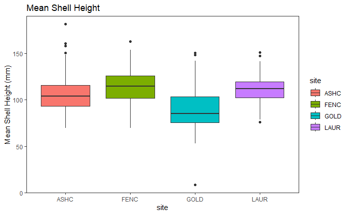

```r
ggplot(data=data_all, aes(x=site, y=height_mm, fill=site)) +
  geom_boxplot()+  #scale_fill_manual(values=c("forestgreen","orange", "purple"))+
  theme_bw() +  theme(panel.grid.major = element_blank(), panel.grid.minor = element_blank())+
  #theme(axis.text.x = element_text(angle = 90, vjust = 0.5, hjust=1))+
  labs(title="Mean Shell Height ", x ="site", y = "Mean Shell Height (mm)")
```

#Mean length

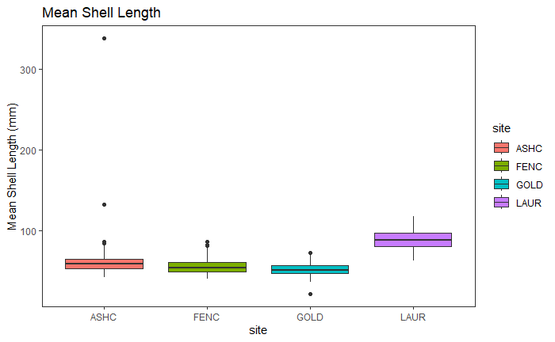

```r
ggplot(data=data_all, aes(x=site, y=length_mm, fill=site)) +
  geom_boxplot()+  #scale_fill_manual(values=c("forestgreen","orange", "purple"))+
  theme_bw() +  theme(panel.grid.major = element_blank(), panel.grid.minor = element_blank())+
  #theme(axis.text.x = element_text(angle = 90, vjust = 0.5, hjust=1))+
  labs(title="Mean Shell Length ", x ="site", y = "Mean Shell Length (mm)")
```

#Mean width

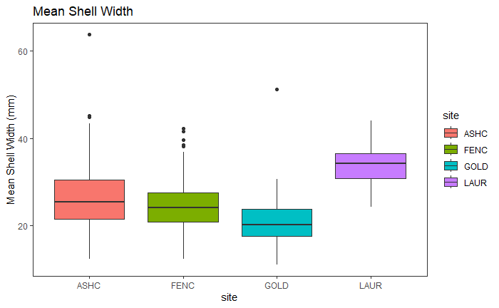

```r
ggplot(data=data_all, aes(x=site, y=width_mm, fill=site)) +
  geom_boxplot()+  #scale_fill_manual(values=c("forestgreen","orange", "purple"))+
  theme_bw() +  theme(panel.grid.major = element_blank(), panel.grid.minor = element_blank())+
  #theme(axis.text.x = element_text(angle = 90, vjust = 0.5, hjust=1))+
  labs(title="Mean Shell Width ", x ="site", y = "Mean Shell Width (mm)")
```

#Body condition

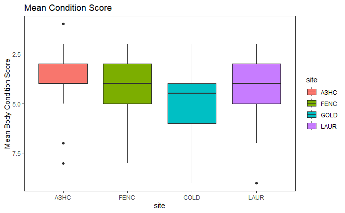

```r
ggplot(data=data_all, aes(x=site, y=condition_score, fill=site)) +
  geom_boxplot()+  #scale_fill_manual(values=c("forestgreen","orange", "purple"))+
  theme_bw() +  theme(panel.grid.major = element_blank(), panel.grid.minor = element_blank())+
  #theme(axis.text.x = element_text(angle = 90, vjust = 0.5, hjust=1))+
  labs(title="Mean Condition Score ", x ="site", y = "Mean Body Condition Score")+ scale_y_reverse()
```

```r
mean_body_condition <- data_all %>%
  dplyr::group_by(site, month)%>%
  dplyr::summarize(mean_bsc = mean(condition_score, na.rm = TRUE))
mean_body_condition
```

| site | month | mean_bsc |
| --- | --- | --- |
| ASHC | 4 | NaN |
| ASHC | 5 | NaN |
| ASHC | 6 | 2.866667 |
| ASHC | 7 | 3.633333 |
| ASHC | 8 | 4.066667 |
| ASHC | 9 | 3.833333 |
| ASHC | 10 | 3.833333 |
| ASHC | 11 | 3.233333 |
| FENC | 4 | NaN |
| FENC | 5 | NaN |

[output cut: 18 more lines]

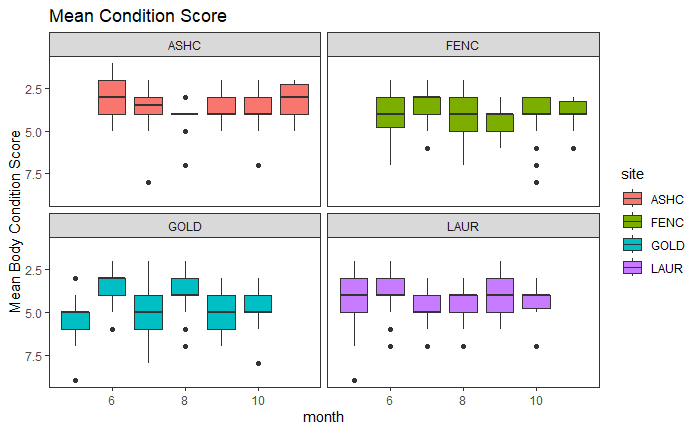

```r
ggplot(data=data_all, aes(x=month, y=condition_score, group = month, fill = site)) +
  geom_boxplot()+
  theme_bw() +  theme(panel.grid.major = element_blank(), panel.grid.minor = element_blank())+
  #theme(axis.text.x = element_text(angle = 90, vjust = 0.5, hjust=1))+
  labs(title="Mean Condition Score ", x ="month", y = "Mean Body Condition Score")+ scale_y_reverse()+facet_wrap(~site)
```

#Proportions graph Body condition scores

```r
data_all
```

| lab_id | date_collected | site | lab_sample | oyster_zone | light_regime | date_processed | ww_total_g | height_mm | length_mm | width_mm | condition | dissection_notes | mantle_rftm | ggr1_etoh...15 | ggr1_etoh...16 | adductor_etoh | cross_histology | date_davidsons | date_etoh | ...21 | ...22 | ...23 | ...24 | ...25 | ...26 | ...27 | ...28 | ...29 | ...30 | … |
| --- | --- | --- | --- | --- | --- | --- | --- | --- | --- | --- | --- | --- | --- | --- | --- | --- | --- | --- | --- | --- | --- | --- | --- | --- | --- | --- | --- | --- | --- | --- |
| 0423ASHC_01 | 2023-04-23 | ASHC | 1 | upper | NA | 2023-04-25 | 70.64 | 98.50 | 51.96 | 24.48 | medium | NA | TRUE | TRUE | TRUE | TRUE | TRUE | 2023-04-25 | 2023-04-26 | NA | NA | NA | NA | NA | NA | NA | NA | NA | NA | … |
| 0423ASHC_02 | 2023-04-23 | ASHC | 2 | upper | NA | 2023-04-25 | 78.83 | 101.82 | 56.09 | 26.11 | medium | NA | TRUE | TRUE | TRUE | TRUE | TRUE | 2023-04-25 | 2023-04-26 | NA | NA | NA | NA | NA | NA | NA | NA | NA | NA | … |
| 0423ASHC_03 | 2023-04-23 | ASHC | 3 | upper | NA | 2023-04-25 | 61.52 | 109.94 | 48.01 | 21.45 | medium | NA | TRUE | TRUE | TRUE | TRUE | TRUE | 2023-04-25 | 2023-04-26 | NA | NA | NA | NA | NA | NA | NA | NA | NA | NA | … |
| 0423ASHC_04 | 2023-04-23 | ASHC | 4 | upper | NA | 2023-04-25 | 66.62 | 79.13 | 54.84 | 23.51 | medium | NA | TRUE | TRUE | TRUE | TRUE | TRUE | 2023-04-25 | 2023-04-26 | NA | NA | NA | NA | NA | NA | NA | NA | NA | NA | … |
| 0423ASHC_05 | 2023-04-23 | ASHC | 5 | upper | NA | 2023-04-25 | 68.72 | 104.60 | 52.72 | 17.76 | medium | NA | TRUE | TRUE | TRUE | TRUE | TRUE | 2023-04-25 | 2023-04-26 | NA | NA | NA | NA | NA | NA | NA | NA | NA | NA | … |
| 0423ASHC_06 | 2023-04-23 | ASHC | 6 | upper | NA | 2023-04-25 | 74.57 | 110.50 | 50.23 | 27.24 | medium | NA | TRUE | TRUE | TRUE | TRUE | TRUE | 2023-04-25 | 2023-04-26 | NA | NA | NA | NA | NA | NA | NA | NA | NA | NA | … |
| 0423ASHC_07 | 2023-04-23 | ASHC | 7 | lower | NA | 2023-04-25 | 39.13 | 75.70 | 43.52 | 22.18 | medium | NA | TRUE | TRUE | TRUE | TRUE | TRUE | 2023-04-25 | 2023-04-26 | NA | NA | NA | NA | NA | NA | NA | NA | NA | NA | … |
| 0423ASHC_08 | 2023-04-23 | ASHC | 8 | upper | NA | 2023-04-25 | 84.88 | 111.31 | 55.33 | 22.61 | medium | NA | TRUE | TRUE | TRUE | TRUE | TRUE | 2023-04-25 | 2023-04-26 | NA | NA | NA | NA | NA | NA | NA | NA | NA | NA | … |
| 0423ASHC_09 | 2023-04-23 | ASHC | 9 | upper | NA | 2023-04-25 | 87.33 | 117.85 | 54.61 | 27.72 | medium | NA | TRUE | TRUE | TRUE | TRUE | TRUE | 2023-04-25 | 2023-04-26 | NA | NA | NA | NA | NA | NA | NA | NA | NA | NA | … |
| 0423ASHC_10 | 2023-04-23 | ASHC | 10 | upper | NA | 2023-04-25 | 155.33 | 134.28 | 69.73 | 25.95 | medium | NA | TRUE | TRUE | TRUE | TRUE | TRUE | 2023-04-25 | 2023-04-26 | NA | NA | NA | NA | NA | NA | NA | NA | NA | NA | … |

[output cut: 828 more lines]

```r
df_BCS_proportions<- data_all %>%
  mutate(condition_score_numeric = as.numeric(condition_score),condition_score_bin = case_when(condition_score == 1 ~ "1", condition_score == 2 ~"2",condition_score == 3 ~ "3", condition_score == 4 ~"4",condition_score == 5 ~ "5", condition_score == 6 ~"6",condition_score == 7 ~ "7", condition_score == 8 ~"8", condition_score ==9 ~"9", TRUE ~ as.character(condition_score))) %>%
  group_by(site, month, condition_score_bin) %>%
  summarise(Count= n()) %>%
  ungroup() %>%
  mutate(Proportion = Count/sum(Count))
df_BCS_proportions<- na.omit(df_BCS_proportions)

df_BCS_proportions
```

| site | month | condition_score_bin | Count | Proportion |
| --- | --- | --- | --- | --- |
| ASHC | 6 | 1 | 5 | 0.005966587 |
| ASHC | 6 | 2 | 8 | 0.009546539 |
| ASHC | 6 | 3 | 8 | 0.009546539 |
| ASHC | 6 | 4 | 4 | 0.004773270 |
| ASHC | 6 | 5 | 5 | 0.005966587 |
| ASHC | 7 | 2 | 3 | 0.003579952 |
| ASHC | 7 | 3 | 12 | 0.014319809 |
| ASHC | 7 | 4 | 11 | 0.013126492 |
| ASHC | 7 | 5 | 3 | 0.003579952 |
| ASHC | 7 | 8 | 1 | 0.001193317 |

[output cut: 114 more lines]

```r
BCS_proportion_all<- ggplot(data=df_BCS_proportions, aes(x=month, y= Proportion, fill=condition_score_bin)) +
  geom_bar(width = .5, stat="identity", position = "fill", colour = "black")+
   theme_bw() +  theme(panel.grid.major = element_blank(), panel.grid.minor = element_blank())+
  theme(axis.text.x = element_text(angle = 45, vjust = 1, hjust=1))+
  labs(title="Proportion of body condition scores April- November", x ="month", y = "Proportion of body condition scores ")+ theme(axis.title.y = element_text(size = rel(1.3), angle =90), axis.title.x = element_text(size = rel(1.3), angle = 0))+
  theme(axis.text=element_text(size=12))+
 scale_fill_brewer() +
  facet_wrap(~ site)

pdf(paste0(path = "C:/Users/mariah.kachmar/Documents/Github/EAD-ASEB_EPA_LISS_Disease_Surveillance/Lab_Data_TissueProcessing" ,"/BCS_proportion_all.pdf"), height = 7, width = 13)
print(BCS_proportion_all)
dev.off()
```

# Ash Creek Summary

```r
df_ASHC<- data_all%>%
  filter(site=="ASHC")
df_ASHC
```

| lab_id | date_collected | site | lab_sample | oyster_zone | light_regime | date_processed | ww_total_g | height_mm | length_mm | width_mm | condition | dissection_notes | mantle_rftm | ggr1_etoh...15 | ggr1_etoh...16 | adductor_etoh | cross_histology | date_davidsons | date_etoh | ...21 | ...22 | ...23 | ...24 | ...25 | ...26 | ...27 | ...28 | ...29 | ...30 | … |
| --- | --- | --- | --- | --- | --- | --- | --- | --- | --- | --- | --- | --- | --- | --- | --- | --- | --- | --- | --- | --- | --- | --- | --- | --- | --- | --- | --- | --- | --- | --- |
| 0423ASHC_01 | 2023-04-23 | ASHC | 1 | upper | NA | 2023-04-25 | 70.64 | 98.50 | 51.96 | 24.48 | medium | NA | TRUE | TRUE | TRUE | TRUE | TRUE | 2023-04-25 | 2023-04-26 | NA | NA | NA | NA | NA | NA | NA | NA | NA | NA | … |
| 0423ASHC_02 | 2023-04-23 | ASHC | 2 | upper | NA | 2023-04-25 | 78.83 | 101.82 | 56.09 | 26.11 | medium | NA | TRUE | TRUE | TRUE | TRUE | TRUE | 2023-04-25 | 2023-04-26 | NA | NA | NA | NA | NA | NA | NA | NA | NA | NA | … |
| 0423ASHC_03 | 2023-04-23 | ASHC | 3 | upper | NA | 2023-04-25 | 61.52 | 109.94 | 48.01 | 21.45 | medium | NA | TRUE | TRUE | TRUE | TRUE | TRUE | 2023-04-25 | 2023-04-26 | NA | NA | NA | NA | NA | NA | NA | NA | NA | NA | … |
| 0423ASHC_04 | 2023-04-23 | ASHC | 4 | upper | NA | 2023-04-25 | 66.62 | 79.13 | 54.84 | 23.51 | medium | NA | TRUE | TRUE | TRUE | TRUE | TRUE | 2023-04-25 | 2023-04-26 | NA | NA | NA | NA | NA | NA | NA | NA | NA | NA | … |
| 0423ASHC_05 | 2023-04-23 | ASHC | 5 | upper | NA | 2023-04-25 | 68.72 | 104.60 | 52.72 | 17.76 | medium | NA | TRUE | TRUE | TRUE | TRUE | TRUE | 2023-04-25 | 2023-04-26 | NA | NA | NA | NA | NA | NA | NA | NA | NA | NA | … |
| 0423ASHC_06 | 2023-04-23 | ASHC | 6 | upper | NA | 2023-04-25 | 74.57 | 110.50 | 50.23 | 27.24 | medium | NA | TRUE | TRUE | TRUE | TRUE | TRUE | 2023-04-25 | 2023-04-26 | NA | NA | NA | NA | NA | NA | NA | NA | NA | NA | … |
| 0423ASHC_07 | 2023-04-23 | ASHC | 7 | lower | NA | 2023-04-25 | 39.13 | 75.70 | 43.52 | 22.18 | medium | NA | TRUE | TRUE | TRUE | TRUE | TRUE | 2023-04-25 | 2023-04-26 | NA | NA | NA | NA | NA | NA | NA | NA | NA | NA | … |
| 0423ASHC_08 | 2023-04-23 | ASHC | 8 | upper | NA | 2023-04-25 | 84.88 | 111.31 | 55.33 | 22.61 | medium | NA | TRUE | TRUE | TRUE | TRUE | TRUE | 2023-04-25 | 2023-04-26 | NA | NA | NA | NA | NA | NA | NA | NA | NA | NA | … |
| 0423ASHC_09 | 2023-04-23 | ASHC | 9 | upper | NA | 2023-04-25 | 87.33 | 117.85 | 54.61 | 27.72 | medium | NA | TRUE | TRUE | TRUE | TRUE | TRUE | 2023-04-25 | 2023-04-26 | NA | NA | NA | NA | NA | NA | NA | NA | NA | NA | … |
| 0423ASHC_10 | 2023-04-23 | ASHC | 10 | upper | NA | 2023-04-25 | 155.33 | 134.28 | 69.73 | 25.95 | medium | NA | TRUE | TRUE | TRUE | TRUE | TRUE | 2023-04-25 | 2023-04-26 | NA | NA | NA | NA | NA | NA | NA | NA | NA | NA | … |

[output cut: 230 more lines]

```r
## Shell Height ##
st_height_ASHC <- summarySE(df_ASHC, measurevar="height_mm", groupvars=c("date_collected"))
st_height_ASHC
```

| date_collected | N | height_mm | sd | se | ci |
| --- | --- | --- | --- | --- | --- |
| 2023-04-23 | 30 | 94.64633 | 15.95791 | 2.913503 | 5.958782 |
| 2023-05-10 | 30 | 116.31067 | 17.53912 | 3.202191 | 6.549216 |
| 2023-06-12 | 30 | 105.11600 | 14.77064 | 2.696738 | 5.515449 |
| 2023-07-10 | 30 | 102.61033 | 15.53491 | 2.836274 | 5.800832 |
| 2023-08-07 | 30 | 110.41600 | 16.23065 | 2.963298 | 6.060624 |
| 2023-09-05 | 30 | 98.20967 | 11.72952 | 2.141507 | 4.379873 |
| 2023-10-03 | 30 | 114.05167 | 21.77399 | 3.975368 | 8.130540 |
| 2023-11-06 | 30 | 107.39133 | 18.79749 | 3.431937 | 7.019099 |

```r
## Body Condition ##
#Excludes April and May due to scoring change. These months are scored categorically 'fat, medium, watery'.

st_condition_ASHC<- summarySE(df_ASHC, measurevar = "condition_score", groupvars = c("date_collected"))
st_condition_ASHC
```

| date_collected | N | condition_score | sd | se | ci |
| --- | --- | --- | --- | --- | --- |
| 2023-04-23 | 30 | NA | NA | NA | NA |
| 2023-05-10 | 30 | NA | NA | NA | NA |
| 2023-06-12 | 30 | 2.866667 | 1.332183 | 0.2432223 | 0.4974455 |
| 2023-07-10 | 30 | 3.633333 | 1.159171 | 0.2116348 | 0.4328417 |
| 2023-08-07 | 30 | 4.066667 | 0.868345 | 0.1585374 | 0.3242453 |
| 2023-09-05 | 30 | 3.833333 | 0.746640 | 0.1363172 | 0.2788000 |
| 2023-10-03 | 30 | 3.833333 | 1.205829 | 0.2201532 | 0.4502639 |
| 2023-11-06 | 30 | 3.233333 | 0.971431 | 0.1773582 | 0.3627383 |

```r
mean_condition_ASHC <- st_condition_ASHC %>%
  filter(!is.na(condition_score)) %>%  # Filter out rows where condition_score is NA
  summarize(mean_bcs = mean(condition_score, na.rm = TRUE))
mean_condition_ASHC
```

| mean_bcs |
| --- |
| 3.577778 |

```r
NA
```

```r
ggplot(data=df_ASHC, aes(x=month, y=height_mm, group= month)) +
  geom_boxplot()+  #scale_fill_manual(values=c("forestgreen","orange", "purple"))+
  theme_bw() +  theme(panel.grid.major = element_blank(), panel.grid.minor = element_blank())+
  #theme(axis.text.x = element_text(angle = 90, vjust = 0.5, hjust=1))+
  labs(title=" Ash Creek Mean Shell Height ", x ="month", y = "Mean Shell Height (mm)")
```

[output not shown]

```r
#Condition distribution across all sample months
ASHC_BCS_dist <-ggplot(data=df_ASHC, aes(x= condition)) +
  geom_bar()+  #scale_fill_manual(values=c("forestgreen","orange", "purple"))+
  theme_bw() +  theme(panel.grid.major = element_blank(), panel.grid.minor = element_blank())+
  #theme(axis.text.x = element_text(angle = 90, vjust = 0.5, hjust=1))+
  labs(title="Ash Creek Body Condition Score ", x ="Condition categorization")+
  facet_wrap(~ month, scales = "free")

pdf(paste0(path = "C:/Users/mariah.kachmar/Documents/Github/EAD-ASEB_EPA_LISS_Disease_Surveillance/Lab_Data_TissueProcessing" ,"/ASHC_BCS_dist.pdf"), height = 7, width = 13)
print(ASHC_BCS_dist)
dev.off()

#Mean Body condition per month
ggplot(data=df_ASHC, aes(x= month, y= condition_score, group = month)) +
  geom_boxplot()+  #scale_fill_manual(values=c("forestgreen","orange", "purple"))+
  theme_bw() +  theme(panel.grid.major = element_blank(), panel.grid.minor = element_blank())+
  #theme(axis.text.x = element_text(angle = 90, vjust = 0.5, hjust=1))+
  labs(title="Ash Creek Mean Body Condition Score ", x ="month", y= " condition score (1-9)") + scale_y_reverse()

## Mean body condition per 'Zone'
ggplot(data=df_ASHC, aes(x= oyster_zone, y= condition_score, group = oyster_zone, fill = oyster_zone)) +
  geom_boxplot()+  #scale_fill_manual(values=c("forestgreen","orange", "purple"))+
  theme_bw() +  theme(panel.grid.major = element_blank(), panel.grid.minor = element_blank())+
  #theme(axis.text.x = element_text(angle = 90, vjust = 0.5, hjust=1))+
  labs(title="Ash Creek Mean Body Condition Score ", x ="Zone", y= " condition score (1-9)") + scale_y_reverse()
```

[output not shown]

#ASHC Proportions graph Body condition scores

```r
ASHC_BCS_proportions<- df_ASHC %>%
  mutate(condition_score_numeric = as.numeric(condition_score),condition_score_bin = case_when(condition_score == 1 ~ "1", condition_score == 2 ~"2",condition_score == 3 ~ "3", condition_score == 4 ~"4",condition_score == 5 ~ "5", condition_score == 6 ~"6",condition_score == 7 ~ "7", condition_score == 8 ~"8", condition_score ==9 ~"9", TRUE ~ as.character(condition_score))) %>%
  group_by(site, month, condition_score_bin) %>%
  summarise(Count= n()) %>%
  ungroup() %>%
  mutate(Proportion = Count/sum(Count))

ASHC_BCS_proportions<- na.omit(ASHC_BCS_proportions)

ASHC_BCS_proportions

BCS_proportion_ASHC<- ggplot(data=ASHC_BCS_proportions, aes(x=month, y= Proportion, fill=condition_score_bin)) +
  geom_bar(width = .5, stat="identity", position = "fill")+
   theme_bw() +  theme(panel.grid.major = element_blank(), panel.grid.minor = element_blank())+
  theme(axis.text.x = element_text(angle = 45, vjust = 1, hjust=1))+
  labs(title="Ash Creek Proportion of body condition scores June- November", x ="month", y = "Proportion of body condition scores ")+ theme(axis.title.y = element_text(size = rel(1.3), angle =90), axis.title.x = element_text(size = rel(1.3), angle = 0))+
  theme(axis.text=element_text(size=12))+
 #scale_fill_brewer() +
  #facet_wrap(~ site)

pdf(paste0(path = "C:/Users/mariah.kachmar/Documents/Github/EAD-ASEB_EPA_LISS_Disease_Surveillance/Lab_Data_TissueProcessing" ,"/BCS_proportion_ASHC.pdf"), height = 7, width = 13)
print(BCS_proportion_ASHC)
dev.off()
```

[output not shown]